# Post 2:Data Cleaning + Preliminary Analysis

Team Rreproduce

2022-10-21

# Introduction

This week we tidy the data and use a subset of data for exploratory analysis.

In **load_and_clean_data.R** file, we made following changes:

- remove all n = 0 entries (there is no one moving between two commute zone) and n = -1 entries (NA value)
- separate the pool variable into race and income
- Use filter function to focus on the population of immigrants moving from Massachusetts
- Change the column names to make them easy to understand
- Change the NA probability to 0 (It was NA because the denominator is 0)

Our subset data **o_MA** is then saved in the dataset file.

# Examining o_MA

```r
library(tidyverse)
o_MA <- read_csv(here::here("dataset/o_MA.csv"))
```

## Plot 1

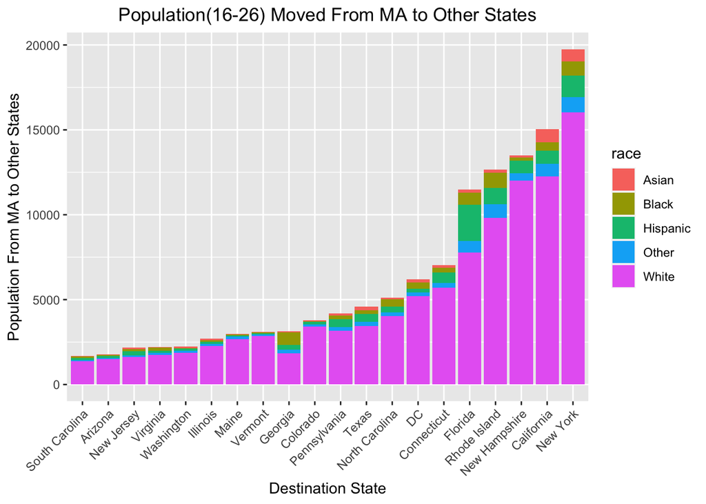

```r
o_MA %>%
  group_by(d_state_name) %>%
  mutate(sum_n = sum(n)) %>%
  ungroup() %>%
  group_by(d_state_name,race) %>%
  mutate(state_race_pop = sum(n)) %>%
  summarize(sum_n=sum_n,state_race_pop=state_race_pop) %>%
  distinct(d_state_name,race,.keep_all = T) %>%
  filter(d_state_name != "Massachusetts") %>%
  ungroup() %>%
  arrange(desc(sum_n)) %>%
  filter(sum_n > 1650) %>%
  ggplot() +
  geom_col(aes(x=reorder(d_state_name,sum_n),y=state_race_pop,fill=race))+
  theme(axis.text.x = element_text(angle=45,vjust=1,hjust=1)) +
  labs(title = "Population(16-26) Moved From MA to Other States",
       x = "Destination State", y = "Population From MA to Other States", color="race") +
  theme(plot.title = element_text(hjust = 0.5))
```

## Plot 2

[figure not shown]

```r
o_MA %>%
  filter(d_state_name =="Massachusetts")%>%
  filter(o_cz=="Boston") %>%
  ggplot()+
  geom_bar(aes(x = d_cz, fill=d_cz))+
  coord_polar(theta='x')
```

## Plot 3

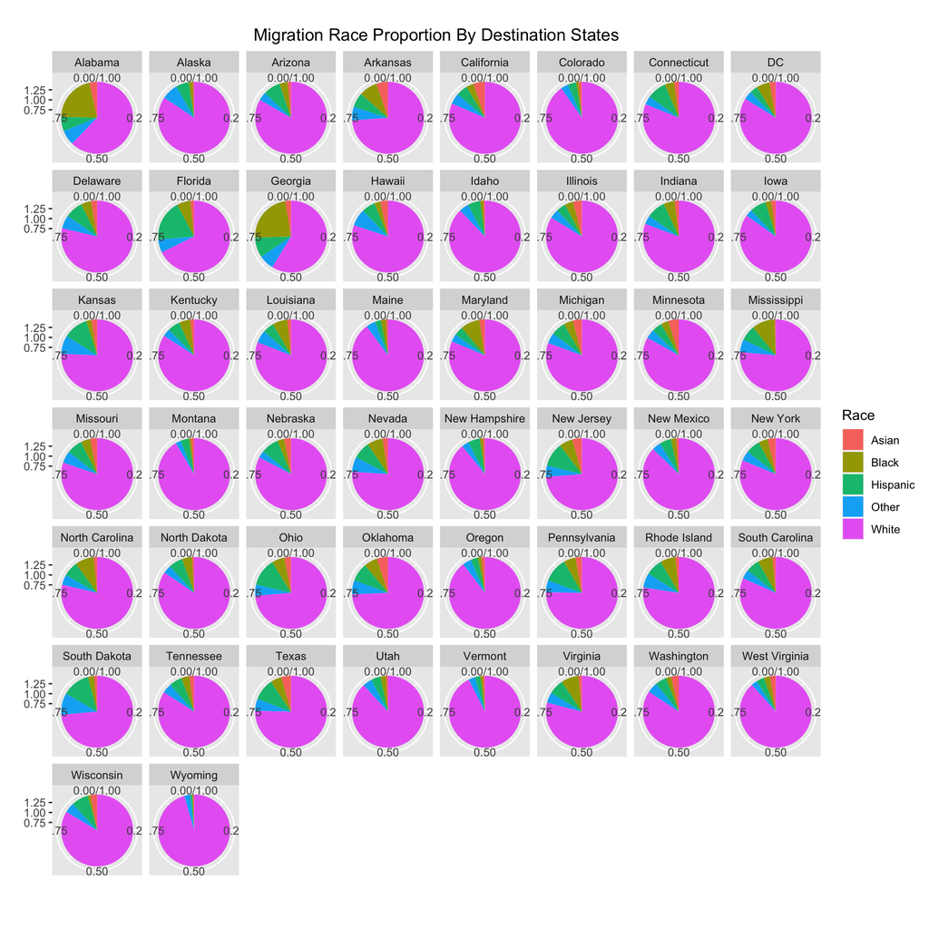

```r
o_MA %>%
  filter(d_state_name!="Massachusetts") %>%
  group_by(d_state_name,race) %>%
  summarize(state_race_pop = sum(n)) %>%
  ggplot() +
  geom_col(aes(x=1,y=state_race_pop,fill=race),position = "fill") +
  facet_wrap(~d_state_name) +
  coord_polar(theta = "y") +
  labs(title = "Migration Race Proportion By Destination States", x="",y="",fill="Race")+
  theme(plot.title = element_text(hjust = 0.5))
```

Among 50 different destination states, white group people are the most likely to migrate. Moreover, white group people make up at least 75 percent of the total migration in each state, except Alabama, Florida, and Georgia. Asian and colored groups have relatively similar migration patterns in most states.

## Plot 4

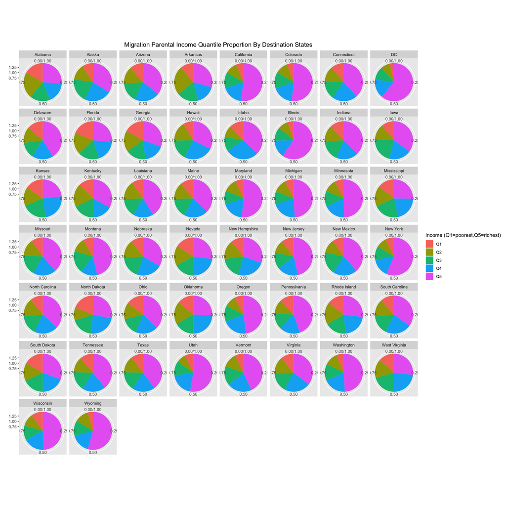

```r
o_MA %>%
  filter(d_state_name!="Massachusetts") %>%
  group_by(d_state_name,income) %>%
  summarize(state_inc_pop = sum(n)) %>%
  ggplot() +
  geom_col(aes(x=1,y=state_inc_pop,fill=income),position = "fill") +
  facet_wrap(~d_state_name) +
  coord_polar(theta = "y")+
  labs(title="Migration Parental Income Quantile Proportion By Destination States",
       x = "", y="",fill="Income (Q1=poorest,Q5=richest)") +
   theme(plot.title = element_text(hjust = 0.5))
```

Among 50 states’ migration population, the Q1 income group ( poorest parental income quintile) has the lowest migrant population in most cases. Surprisingly, the migration pattern in 10 of the states is very similar: people from 5 different income groups contribute a relatively equal number of the migrating population.